# Machine Language

Sudhakarreddy M

December 2, 2017

## Synopsys

Using devices such as Jawbone Up, Nike FuelBand, and Fitbit it is now possible to collect a large amount of data about personal activity relatively inexpensively. These type of devices are part of the quantified self movement – a group of enthusiasts who take measurements about themselves regularly to improve their health, to find patterns in their behavior, or because they are tech geeks. One thing that people regularly do is quantify how much of a particular activity they do, but they rarely quantify how well they do it.

This project uses the data from accelerometers on the belt, forearm, arm, and dumbell of 6 participants in which they were asked to perform barbell lifts correctly and incorrectly in 5 different ways. The goal of the project is to predict the manner in which they did the exercise

The training data for this project are available here:

https://d396qusza40orc.cloudfront.net/predmachlearn/pml-training.csv

The test data are available here:

https://d396qusza40orc.cloudfront.net/predmachlearn/pml-testing.csv

The data for this project come from this source: http://groupware.les.inf.puc-rio.br/har

## Data Processing

Download the files from the given URLs and read them in to separate dataframes. Eliminate the columns with missing values.

```r
trainingurl <- "https://d396qusza40orc.cloudfront.net/predmachlearn/pml-training.csv"
testurl <- "https://d396qusza40orc.cloudfront.net/predmachlearn/pml-testing.csv"

setwd("C:/Users/s.maramreddy/OneDrive - Accenture/Personal/R/Machine Lang/")

download.file(trainingurl, "trngfiledwd.csv")
download.file(testurl, "tstfiledwd.csv")

trngfile <- read.csv("trngfiledwd.csv",na.strings=c("NA","#DIV/0!", ""))
testfile <- read.csv("tstfiledwd.csv",na.strings=c("NA","#DIV/0!", ""))

trngfile<-trngfile[,colSums(is.na(trngfile)) == 0]
testfile <-testfile[,colSums(is.na(testfile)) == 0]

trngfile  <-trngfile[,-c(1:7)]
testfile <-testfile[,-c(1:7)]
```

### Cross Validation:

Create the cross validation training set by taking 30% of the data from the given training test. Below I have used 2 different models (Random Forest and boosted) for prediction and comparison of accuracy

```r
cvalind <- createDataPartition(y=trngfile$classe, p=0.3, list=FALSE)
cvaltrngfile <- trngfile[cvalind,]
cvaltestfile <- trngfile[-cvalind,]
```

### Exploratory Analysis

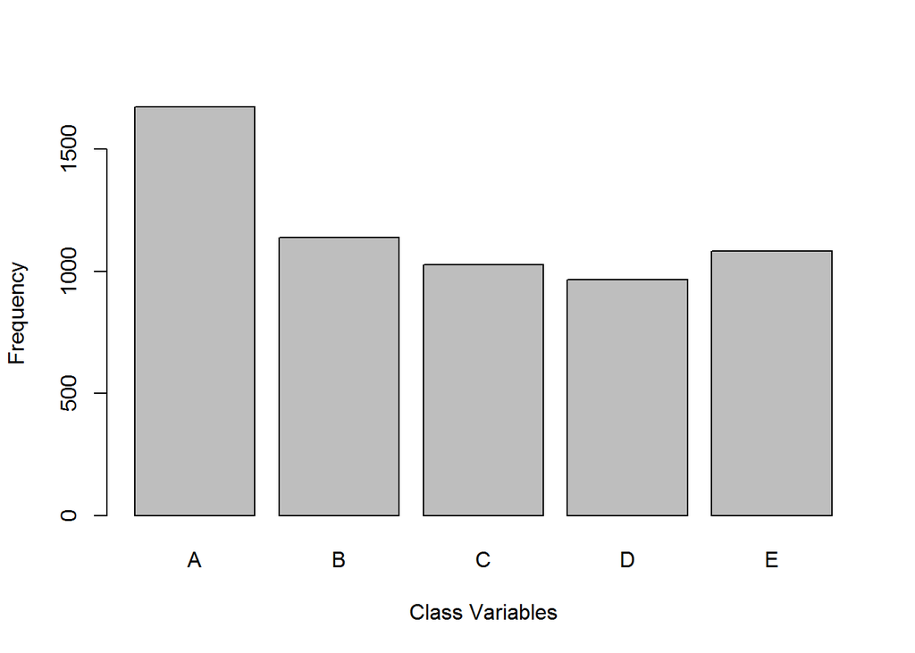

```r
plot(cvaltrngfile$classe, xlab="Class Variables", ylab="Frequency")
```

### Prediction models

```r
ctrl = trainControl(method='cv',number=5,repeats=2,returnResamp='none')
fit1 <- train(classe~., data=cvaltrngfile, method="gbm",trControl=ctrl)
pred <- predict(fit1, cvaltestfile)
confusionMatrix(pred, cvaltestfile$classe)
```

```
## Confusion Matrix and Statistics
##
##           Reference
## Prediction    A    B    C    D    E
##          A 3868  121    0    7    2
##          B   25 2418   78    4   23
##          C    7  102 2286   85   30
##          D    4    8   29 2124   34
##          E    2    8    2   31 2435
##
## Overall Statistics
##
##                Accuracy : 0.9562
##                  95% CI : (0.9526, 0.9595)
##     No Information Rate : 0.2844
##     P-Value [Acc > NIR] : < 2.2e-16
##
##                   Kappa : 0.9445
##  Mcnemar's Test P-Value : < 2.2e-16
##
## Statistics by Class:
##
##                      Class: A Class: B Class: C Class: D Class: E
## Sensitivity            0.9903   0.9100   0.9545   0.9436   0.9647
## Specificity            0.9868   0.9883   0.9802   0.9935   0.9962
## Pos Pred Value         0.9675   0.9490   0.9108   0.9659   0.9826
## Neg Pred Value         0.9961   0.9786   0.9903   0.9890   0.9921
## Prevalence             0.2844   0.1935   0.1744   0.1639   0.1838
## Detection Rate         0.2817   0.1761   0.1665   0.1547   0.1773
## Detection Prevalence   0.2911   0.1855   0.1828   0.1601   0.1804
## Balanced Accuracy      0.9885   0.9492   0.9674   0.9685   0.9805
```

```r
fit2 <- train(classe~., data=cvaltrngfile, method="rf",trControl=ctrl)
pred2 <- predict(fit2, cvaltestfile)
confusionMatrix(pred2, cvaltestfile$classe)
```

```
## Confusion Matrix and Statistics
##
##           Reference
## Prediction    A    B    C    D    E
##          A 3883   53    0    1    9
##          B   17 2556   31   11    4
##          C    1   36 2351   56   19
##          D    3   12   13 2177   19
##          E    2    0    0    6 2473
##
## Overall Statistics
##
##                Accuracy : 0.9787
##                  95% CI : (0.9761, 0.981)
##     No Information Rate : 0.2844
##     P-Value [Acc > NIR] : < 2.2e-16
##
##                   Kappa : 0.973
##  Mcnemar's Test P-Value : 2.087e-13
##
## Statistics by Class:
##
##                      Class: A Class: B Class: C Class: D Class: E
## Sensitivity            0.9941   0.9620   0.9816   0.9671   0.9798
## Specificity            0.9936   0.9943   0.9901   0.9959   0.9993
## Pos Pred Value         0.9840   0.9759   0.9545   0.9789   0.9968
## Neg Pred Value         0.9976   0.9909   0.9961   0.9936   0.9955
## Prevalence             0.2844   0.1935   0.1744   0.1639   0.1838
## Detection Rate         0.2827   0.1861   0.1712   0.1585   0.1801
## Detection Prevalence   0.2873   0.1907   0.1793   0.1619   0.1807
## Balanced Accuracy      0.9939   0.9781   0.9859   0.9815   0.9895
```

Now do the prediction on the unknown activities

```r
predtest <- predict(fit2, testfile)

finalresult <- as.character(predtest)
```

## Results

```r
predwritefiles = function(z){
  n = length(z)
  for(i in 1:n){
    filename = paste0("problem_id_",i,".txt")
    write.table(z[i],file=filename,quote=FALSE,row.names=FALSE,col.names=FALSE)
  }
}

predwritefiles(finalresult)
```

## Conclusion: As per the confusion matrix, we are able to predict 98% accuracry with Random Forest algorithm and 95% Accuracy with Gradient Boosting algorithm